**Secretaría del Bienestar para la Comunidad**Presidencia Municipal de Mineral de la Reforma, Hidalgo

3ª edición del Festival Chicomecóatl

# Callejón de los Recuerdos y catrinas

Una instalación artística en ocho descansos que rinde homenaje a nuestros difuntos y a las tradiciones de la región. Cada secretaría decora un descanso y prepara su catrina. Elige tu área para ver lo que te toca.

30 de octubre al 4 de noviembrePachuquillaInauguración: viernes 30, 19:00 h

Responsable del callejón y de los concursos: **Andrés Vaca, “El Mago”** (Bienestar), 771 204 7150

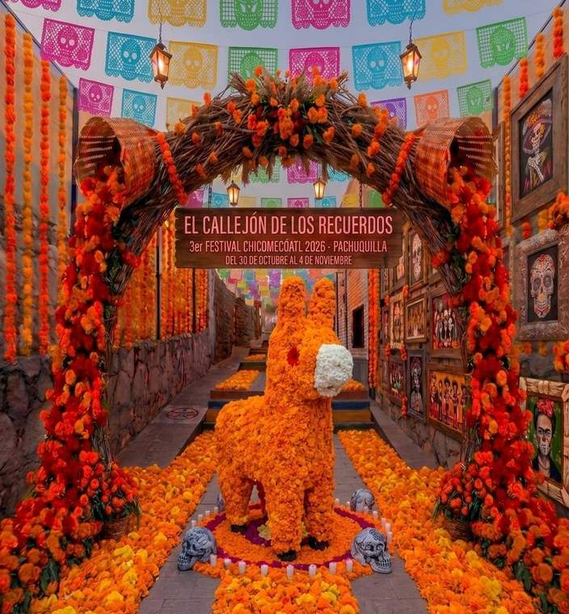

Propuesta para la entrada del callejón

## Responsables

¿Dudas? Comunícate con quien coordina cada parte del festival.

Programa de actividades y personal de apoyoMtro. Luis Alonso López ViteSecretaría del Bienestar para la Comunidad 771 776 3794

Llamar[WhatsApp](https://wa.me/527717763794)

Responsable de esta sección Callejón de los Recuerdos y concursosAndrés Vaca, “El Mago”Secretaría del Bienestar para la Comunidad 771 204 7150

Llamar[WhatsApp](https://wa.me/527712047150)

PanteonesFátima CarrilloSecretaría del Bienestar para la Comunidad 771 146 2931

Llamar[WhatsApp](https://wa.me/527711462931)